# Final Project

# Research Objective

Trump’s presidency is unique from other presidents in the manner he communicates public and economic policy via social media. We want to examine whether his remarks during this global pandemic (Mid March through April 2020) have tangible effects on the stock market. We’re going to analyze the text from daily White House briefings using sentiment analysis. Compare and contrast the sentiment analysis with the stock market performance during his presidency and Trump’s approval ratings.

## Necessary R Packages:

The following libraries are used throughout our analysis:

- **twitteR**
- **quantmod**
- **rvest**
- **stringr**
- **purr**
- **tidytext**
- **dplyr**
- **tidyr**
- **ggplot2**
- **lubridate**
- **RCurl**

# Gather Data

## Daily Presidential White House Briefings

These URLs all end in a number so we’re going to first create a list of URLs & use **read_html** to grab the **< p > tags** for each page

```r
base_url <- 'https://www.whitehouse.gov/briefings-statements/remarks-president-trump-vice-president-pence-members-coronavirus-task-force-press-briefing-'

getPageURLs <- function(url) {
   add_number <- seq(2,33)
   urls <- str_c(base_url, add_number)
   return(urls)
}

urls <- getPageURLs(urls)
head(urls)
```

```
## [1] "https://www.whitehouse.gov/briefings-statements/remarks-president-trump-vice-president-pence-members-coronavirus-task-force-press-briefing-2"
## [2] "https://www.whitehouse.gov/briefings-statements/remarks-president-trump-vice-president-pence-members-coronavirus-task-force-press-briefing-3"
## [3] "https://www.whitehouse.gov/briefings-statements/remarks-president-trump-vice-president-pence-members-coronavirus-task-force-press-briefing-4"
## [4] "https://www.whitehouse.gov/briefings-statements/remarks-president-trump-vice-president-pence-members-coronavirus-task-force-press-briefing-5"
## [5] "https://www.whitehouse.gov/briefings-statements/remarks-president-trump-vice-president-pence-members-coronavirus-task-force-press-briefing-6"
## [6] "https://www.whitehouse.gov/briefings-statements/remarks-president-trump-vice-president-pence-members-coronavirus-task-force-press-briefing-7"
```

```r
wh_briefings <- purrr::map(urls, ~read_html(.x) %>% html_nodes("p") %>% html_text())
wh_dates <- purrr::map(urls, ~read_html(.x) %>% html_nodes("p") %>% html_node("time") %>% html_text())
```

## Stock Market Data

We decided it would be best to compare smallCapFunds, midCapFunds, and largeCapFunds.

```r
start<- as.Date("2020-03-15")
end <- as.Date("2020-04-30")


#Retrieving information on Top 5 Small Growth Funds as ranked by "U.S. News"
smallCapFunds <- c("PSGAX", "FKASX", "PGSGX", "QUASX", "TRSSX")
getSymbols(smallCapFunds, src = "yahoo", from = start, to = end)
```

[output not shown]

```
## [1] "PSGAX" "FKASX" "PGSGX" "QUASX" "TRSSX"
```

```r
#Retreiving information on Top 5 Mid Growth Funds as ranked by "U.S. News"
midCapFunds <- c("DFDMX", "CCSMX","PRDMX", "OTCAX", "BMGAX")
getSymbols(midCapFunds, src = "yahoo", from = start, to = end)
```

```
## [1] "DFDMX" "CCSMX" "PRDMX" "OTCAX" "BMGAX"
```

```r
#Retrieving information on Top 5 Large Growth Funds as ranked by "U.s News"
largeCapFunds <- c("TRLGX", "PREFX", "TPLGX", "FDSVX", "PBLAX")
getSymbols(largeCapFunds, src = "yahoo", from = start, to = end)
```

```
## [1] "TRLGX" "PREFX" "TPLGX" "FDSVX" "PBLAX"
```

```r
#Retrieve Dow Jones Industrial Average
getSymbols("DJIA", src = "yahoo", from = start, to = end)
```

```
## [1] "DJIA"
```

```r
# glimpse data
dplyr::glimpse(PSGAX)
```

```
## An 'xts' object on 2020-03-16/2020-04-29 containing:
##   Data: num [1:32, 1:6] 30.3 31.4 29.3 30.5 29.2 ...
##  - attr(*, "dimnames")=List of 2
##   ..$ : NULL
##   ..$ : chr [1:6] "PSGAX.Open" "PSGAX.High" "PSGAX.Low" "PSGAX.Close" ...
##   Indexed by objects of class: [Date] TZ: UTC
##   xts Attributes:
## List of 2
##  $ src    : chr "yahoo"
##  $ updated: POSIXct[1:1], format: "2020-05-09 13:38:07"
```

## [Trump Approval Ratings](https://projects.fivethirtyeight.com/trump-approval-ratings/)

These ratings were available on FiveThiryEight broken out by Votes,Adults, and All Polls for each day during April 2020.

```r
#github URL
theURL <- getURL("https://raw.githubusercontent.com/geeman1209/MSDATA2020/master/DATA607/Final_Project/approval_topline.csv")
# Read csv from github
trump_apprdf <- read.csv(text = theURL,stringsAsFactors = FALSE)
# glimpse data
dplyr::glimpse(trump_apprdf)
```

```
## Observations: 3,582
## Variables: 10
## $ president           <chr> "Donald Trump", "Donald Trump", "Donald Trump",...
## $ subgroup            <chr> "Voters", "Adults", "All polls", "Adults", "Vot...
## $ modeldate           <chr> "4/30/2020", "4/30/2020", "4/30/2020", "4/29/20...
## $ approve_estimate    <dbl> 42.84215, 43.65953, 42.92110, 43.02131, 42.7230...
## $ approve_hi          <dbl> 46.74216, 47.53337, 46.79893, 46.37986, 46.5450...
## $ approve_lo          <dbl> 38.94214, 39.78569, 39.04326, 39.66275, 38.9010...
## $ disapprove_estimate <dbl> 52.64487, 51.65192, 52.38926, 52.15911, 52.6146...
## $ disapprove_hi       <dbl> 56.27713, 56.48534, 56.54765, 56.86387, 56.2020...
## $ disapprove_lo       <dbl> 49.01261, 46.81850, 48.23088, 47.45436, 49.0272...
## $ timestamp           <chr> "15:46:08 30 Apr 2020", "15:44:36 30 Apr 2020",...
```

# Cleaning Data

## Clean WH Briefing Data

```r
#create empty dataframe
testFrame <- data.frame(date = character(),
                        stringsAsFactors = FALSE)

for (i in 1:length(wh_dates)){
  testFrame <- rbind(testFrame,cbind(as.data.frame(unlist(wh_dates[[i]]),stringsAsFactors = FALSE),i))
}

dateFrame <- na.omit(testFrame)
```

```r
data0 <- data.frame(text=character(),
                   Day=integer(),
                 stringsAsFactors=FALSE)

for (i in 1:length(wh_briefings)){
  data0 <- rbind(data0,cbind(as.data.frame(unlist(wh_briefings[[i]]),stringsAsFactors = FALSE),i))
}

colnames(data0) <- c('text','day')
```

```r
correctMatch <- inner_join(dateFrame,data0,by= c("i" = "day"))
colnames(correctMatch) <- c('date', 'day', 'text')

wh_data <- correctMatch
```

```r
tidy_data <- wh_data %>%
  mutate(linenumber = row_number()) %>%
  ungroup() %>%
  unnest_tokens(word, text)

head(tidy_data)
```

```
##               date day linenumber       word
## 1   March 15, 2020   1          1    remarks
## 2   March 15, 2020   1          2 healthcare
## 3   March 15, 2020   1          3     issued
## 3.1 March 15, 2020   1          3         on
## 3.2 March 15, 2020   1          3      march
## 3.3 March 15, 2020   1          3         15
```

## Clean Approval Ratings

```r
# modeldate - convert into date
trump_apprdf$modeldate <- mdy(trump_apprdf$modeldate)
dplyr::glimpse(trump_apprdf)
```

```
## Observations: 3,582
## Variables: 10
## $ president           <chr> "Donald Trump", "Donald Trump", "Donald Trump",...
## $ subgroup            <chr> "Voters", "Adults", "All polls", "Adults", "Vot...
## $ modeldate           <date> 2020-04-30, 2020-04-30, 2020-04-30, 2020-04-29...
## $ approve_estimate    <dbl> 42.84215, 43.65953, 42.92110, 43.02131, 42.7230...
## $ approve_hi          <dbl> 46.74216, 47.53337, 46.79893, 46.37986, 46.5450...
## $ approve_lo          <dbl> 38.94214, 39.78569, 39.04326, 39.66275, 38.9010...
## $ disapprove_estimate <dbl> 52.64487, 51.65192, 52.38926, 52.15911, 52.6146...
## $ disapprove_hi       <dbl> 56.27713, 56.48534, 56.54765, 56.86387, 56.2020...
## $ disapprove_lo       <dbl> 49.01261, 46.81850, 48.23088, 47.45436, 49.0272...
## $ timestamp           <chr> "15:46:08 30 Apr 2020", "15:44:36 30 Apr 2020",...
```

```r
# filter data for April, 2020
trump_apprsubdf <- trump_apprdf %>%
  filter(modeldate >= as.Date("2020-04-01"))
```

# Data Analysis

## White House Briefing & Sentiment Analysis

```r
# Using lexicon affin
affinLex <- get_sentiments("afinn")
wh.affin <- tidy_data %>%
  anti_join(stop_words) %>%
  group_by(day) %>%
  inner_join(affinLex) %>%
  summarise(sentiment = sum(value)) %>%
  mutate(method="affin")
wh.affin
```

```
## # A tibble: 32 x 3
##      day sentiment method
##    <int>     <dbl> <chr>
##  1     1       172 affin
##  2     2        43 affin
##  3     3       243 affin
##  4     4       114 affin
##  5     5       228 affin
##  6     6       142 affin
##  7     7       207 affin
##  8     8       152 affin
##  9     9       190 affin
## 10    10       174 affin
## # ... with 22 more rows
```

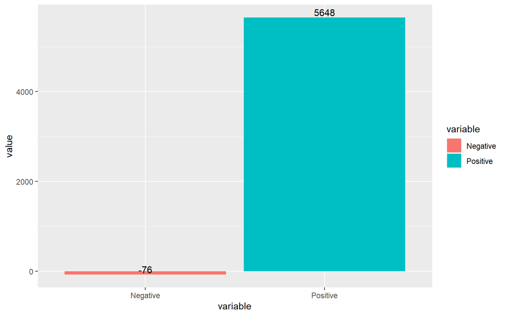

```r
# bar plot for positive and negative cumulative score
wh.affin %>%
  summarise(Positive = sum(sentiment[sentiment>0]), Negative = sum(sentiment[sentiment<0])) %>%
  gather(variable, value, Positive:Negative) %>%
  ggplot(aes(variable, value,  fill = variable)) +
  geom_bar(stat="identity") +
  geom_text(aes(label=value), position=position_dodge(width=0.9), vjust=-0.25)
```

```r
# Using lexicon bing

bingLex <- get_sentiments("bing")
wh.bing <- tidy_data %>%
  anti_join(stop_words) %>%
  group_by(day) %>%
  inner_join(bingLex) %>%
  count(day, sentiment) %>%
  spread(sentiment, n, fill=0) %>%
  mutate(sentiment = positive - negative) %>%
  mutate(method="bing")
wh.bing
```

```
## # A tibble: 32 x 5
## # Groups:   day [32]
##      day negative positive sentiment method
##    <int>    <dbl>    <dbl>     <dbl> <chr>
##  1     1      125      187        62 bing
##  2     2      178      141       -37 bing
##  3     3      230      241        11 bing
##  4     4      180      180         0 bing
##  5     5      204      295        91 bing
##  6     6      241      274        33 bing
##  7     7      246      295        49 bing
##  8     8      333      295       -38 bing
##  9     9       97      143        46 bing
## 10    10      168      220        52 bing
## # ... with 22 more rows
```

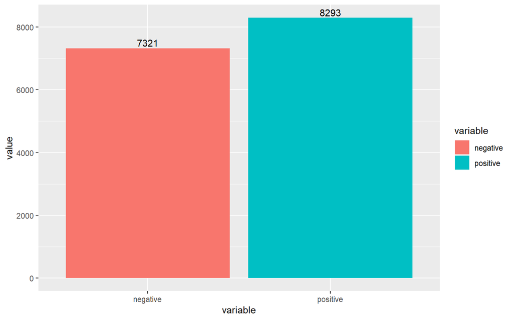

```r
# bar plot for positive and negative sentiments
wh.bing %>%
  ungroup() %>%
  select(-day) %>%
  select(negative, positive) %>%
  summarise_all(funs(sum)) %>%
  gather(variable, value, negative:positive) %>%
  ggplot(aes(variable, value,  fill = variable)) +
  geom_bar(stat="identity") +
  geom_text(aes(label=value), position=position_dodge(width=0.9), vjust=-0.25)
```

```r
# Using lexicon nrc

nrcLex <- get_sentiments("nrc")
wh.nrc <- tidy_data %>%
  anti_join(stop_words) %>%
  group_by(day) %>%
  inner_join(nrcLex) %>%
  filter(sentiment %in% c("positive", "negative")) %>%
  count(day, sentiment) %>%
  spread(sentiment, n, fill=0) %>%
  mutate(sentiment = positive - negative) %>%
  mutate(method="nrc")
wh.nrc
```

```
## # A tibble: 32 x 5
## # Groups:   day [32]
##      day negative positive sentiment method
##    <int>    <dbl>    <dbl>     <dbl> <chr>
##  1     1      145      496       351 nrc
##  2     2      198      503       305 nrc
##  3     3      251      710       459 nrc
##  4     4      226      540       314 nrc
##  5     5      256      691       435 nrc
##  6     6      282      804       522 nrc
##  7     7      318      838       520 nrc
##  8     8      412      884       472 nrc
##  9     9      108      341       233 nrc
## 10    10      217      587       370 nrc
## # ... with 22 more rows
```

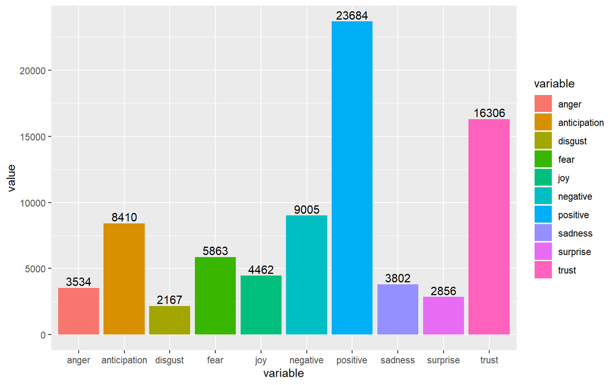

```r
# bar graph for all categories in nrc lexicon
tidy_data %>%
  anti_join(stop_words) %>%
  group_by(day) %>%
  inner_join(nrcLex) %>%
  #filter(sentiment %in% c("positive", "negative")) %>%
  count(day, sentiment) %>%
  spread(sentiment, n, fill=0) %>%
  ungroup() %>%
  select(-day) %>%
  summarise_all(funs(sum)) %>%
  gather(variable, value, anger:trust) %>%
  ggplot(aes(variable, value,  fill = variable)) +
  geom_bar(stat="identity") +
  geom_text(aes(label=value), position=position_dodge(width=0.9), vjust=-0.25)
```

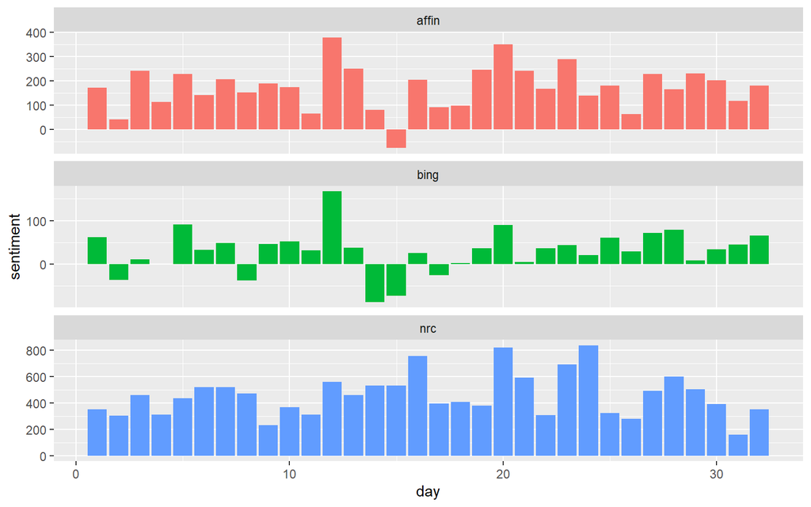

```r
# Comparing all 3 lexicons

wh.aff_bin_nrc <- bind_rows(wh.affin, wh.bing, wh.nrc)
bind_rows(wh.aff_bin_nrc) %>%
  ggplot(aes(day, sentiment, fill = method)) +
  geom_col(show.legend = FALSE) +
  facet_wrap(~method, ncol = 1, scales = "free_y")
```

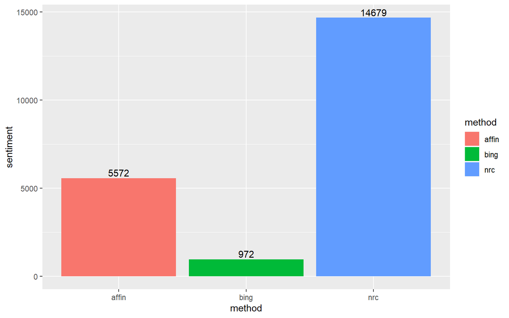

```r
# comparing the cumulative sentiments for all 3 lexicons
wh.aff_bin_nrc %>%
  group_by(method) %>%
  summarise(sentiment = sum(sentiment)) %>%
  ggplot(aes(method, sentiment, fill = method)) +
  geom_bar(stat="identity") +
  geom_text(aes(label=sentiment), position=position_dodge(width=0.9), vjust=-0.25)
```

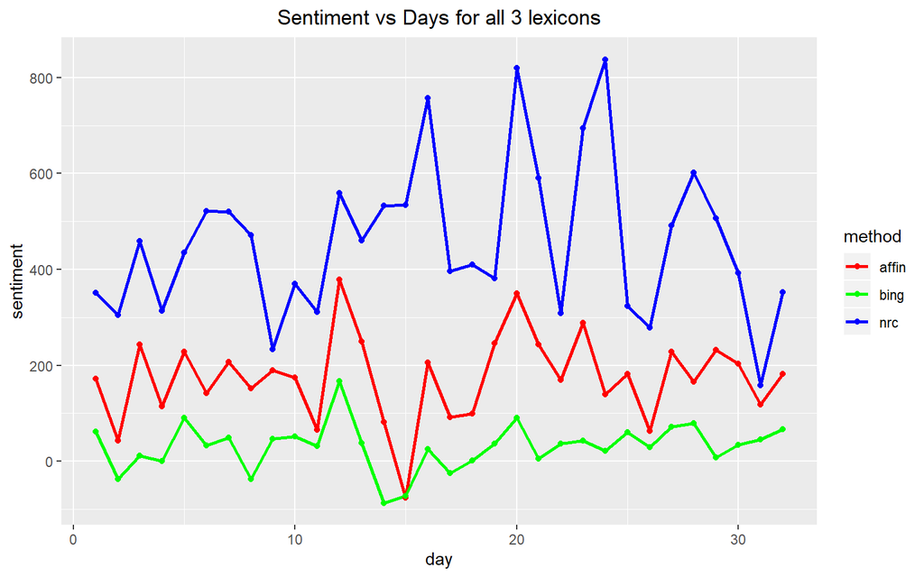

```r
# line graph for all 3 lexicons
wh.aff_bin_nrc %>%
  ggplot(aes(x=day, y=sentiment, group=method, color=method)) +
  geom_line(size=1) +
  geom_point() + labs(x="day", y="sentiment", title = "Sentiment vs Days for all 3 lexicons") +
  scale_color_manual(values=c("red", "green", "blue")) +
  theme(plot.title = element_text(hjust = 0.5))
```

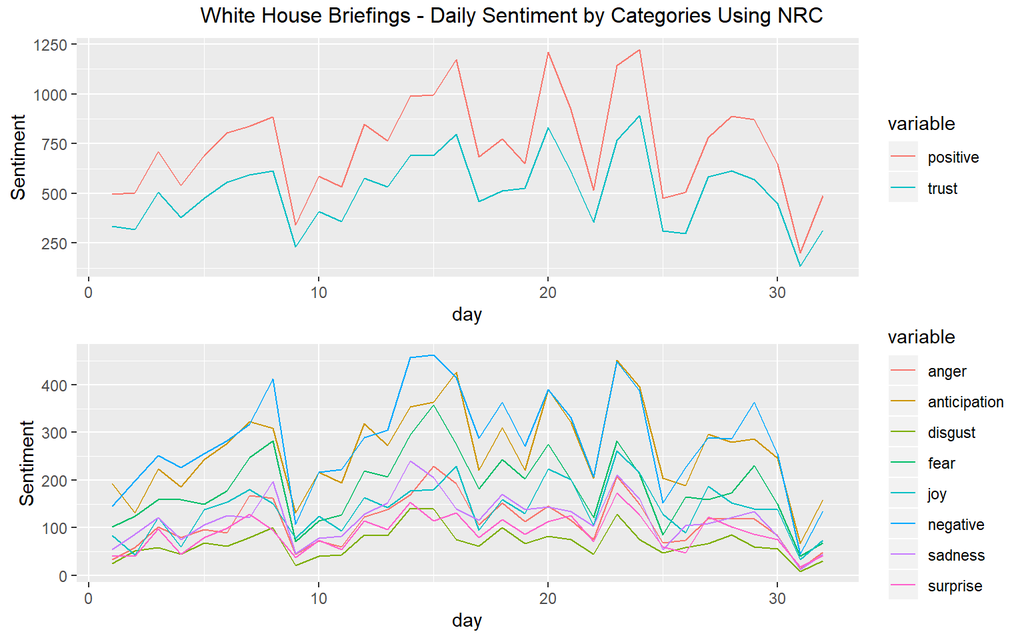

```r
a <- tidy_data %>%
  anti_join(stop_words) %>%
  inner_join(nrcLex) %>%
  count(day, sentiment) %>%
  spread(sentiment, n, fill=0) %>%
  gather(variable, value, c('positive','trust')) %>%
  ggplot(aes(day, value,  color = variable,fill = variable)) +
  geom_line(stat="identity") +
  ylab('Sentiment')
b <- tidy_data %>%
  anti_join(stop_words) %>%
  inner_join(nrcLex) %>%
  count(day, sentiment) %>%
  spread(sentiment, n, fill=0) %>%
  gather(variable, value, c('anger','anticipation','disgust','fear','joy','negative','sadness','surprise')) %>%
  ggplot(aes(day, value,  color = variable,fill = variable)) +
  geom_line(stat="identity") +
  ylab('Sentiment')
ggarrange(a, b, ncol=1,top = "White House Briefings - Daily Sentiment by Categories Using NRC")
```

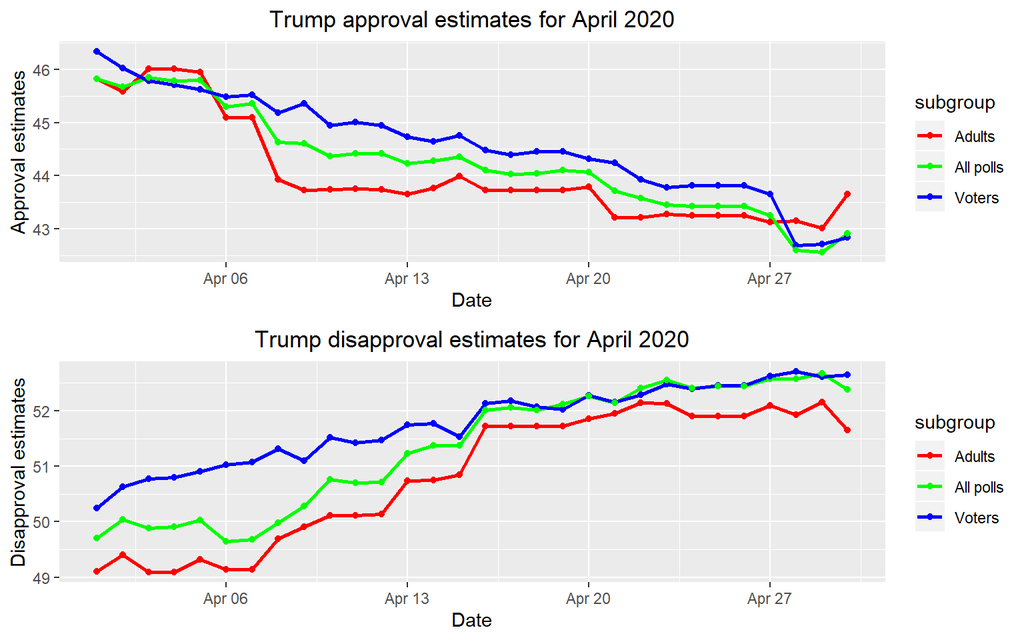

```r
# Disapproval line plot for all 3 sub groups
disapprove <- trump_apprsubdf %>%
  ggplot(aes(x=modeldate,y=disapprove_estimate, group=subgroup, color=subgroup)) +
  geom_line(size=1) +
  geom_point() + labs(x="Date", y="Disapproval estimates", title = "") +
  scale_color_manual(values=c("red", "green", "blue")) +
  ggtitle('Trump disapproval estimates for April 2020')+
  theme(plot.title = element_text(hjust = 0.5))

# Approval line plot for all 3 sub groups
approve <- trump_apprsubdf %>%
  ggplot(aes(x=modeldate,y=approve_estimate, group=subgroup, color=subgroup)) +
  geom_line(size=1) +
  geom_point() + labs(x="Date", y="Approval estimates", title = "") +
  scale_color_manual(values=c("red", "green", "blue")) +
  ggtitle('Trump approval estimates for April 2020')+
  theme(plot.title = element_text(hjust = 0.5))

ggarrange(approve, disapprove, ncol=1)
```

```r
smFrame <- dateFrame
colnames(smFrame) <- c("Date","Day")

smFrame$PSGAX_Close <- PSGAX$PSGAX.Close
smFrame$FKASX_Close <- FKASX$FKASX.Close
smFrame$PGSGX_Close <- PGSGX$PGSGX.Close
smFrame$QUASX_Close <- QUASX$QUASX.Close
smFrame$TRSSX_Close <- TRSSX$TRSSX.Close


smFrame$Sentiment <- wh.bing$sentiment
```

```r
tstFrame <- smFrame

tstFrame$AvgClose <- (smFrame$PSGAX_Close + smFrame$FKASX_Close + smFrame$PGSGX_Close + smFrame$TRSSX_Close + smFrame$QUASX_Close)/5

SmLm2 <- lm(AvgClose ~ Sentiment, data= tstFrame)

summary(SmLm2)
```

```
##
## Call:
## lm(formula = AvgClose ~ Sentiment, data = tstFrame)
##
## Residuals:
##     Min      1Q  Median      3Q     Max
## -4.6750 -1.7080  0.1007  1.6570  4.5108
##
## Coefficients:
##              Estimate Std. Error t value Pr(>|t|)
## (Intercept) 28.955444   0.513187  56.423   <2e-16 ***
## Sentiment    0.011512   0.008987   1.281     0.21
## ---
## Signif. codes:  0 '***' 0.001 '**' 0.01 '*' 0.05 '.' 0.1 ' ' 1
##
## Residual standard error: 2.458 on 30 degrees of freedom
## Multiple R-squared:  0.05186,    Adjusted R-squared:  0.02026
## F-statistic: 1.641 on 1 and 30 DF,  p-value: 0.21
```

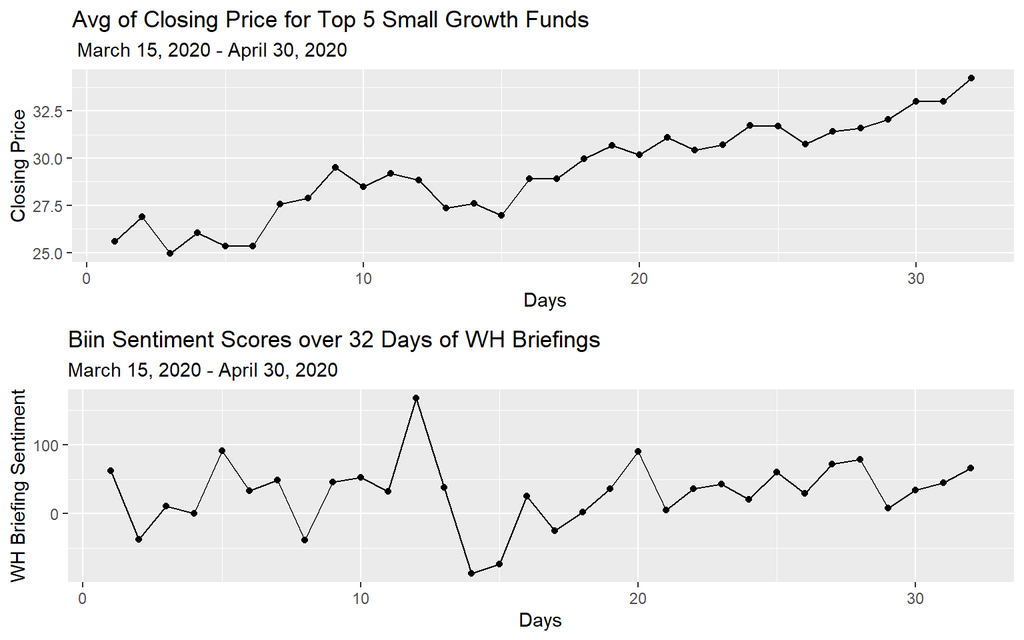

```r
plot1 <- tstFrame %>%
ggplot(aes(x=Day, y=AvgClose, group=1)) +
    geom_line() +
    geom_point() + labs(x=" Days", y="Closing Price", title = "Avg of Closing Price for Top 5 Small Growth Funds", subtitle = " March 15, 2020 - April 30, 2020")

plot2 <- tstFrame %>%
ggplot(aes(x=Day, y=Sentiment, group=1)) +
    geom_line() +
    geom_point() + labs(x="Days", y="WH Briefing Sentiment", title = "Biin Sentiment Scores over 32 Days of WH Briefings", subtitle = "March 15, 2020 - April 30, 2020")

grid.arrange(plot1, plot2, nrow = 2)
```

```r
mdFrame <- dateFrame
colnames(mdFrame) <- c("Date","Day")

mdFrame$DFDMX_Close <- DFDMX$DFDMX.Close
mdFrame$CCSMX_Close <- CCSMX$CCSMX.Close
mdFrame$PRDMX_Close <- PRDMX$PRDMX.Close
mdFrame$OTCAX_Close <- OTCAX$OTCAX.Close
mdFrame$BMGAX_Close <- BMGAX$BMGAX.Close


mdFrame$Sentiment <- wh.bing$sentiment
```

```r
tst2Frame <- mdFrame

tst2Frame$AvgClose <- (mdFrame$DFDMX_Close + mdFrame$CCSMX_Close + mdFrame$PRDMX_Close + mdFrame$OTCAX_Close + mdFrame$BMGAX_Close)/5

SmLm3 <- lm(AvgClose ~ Sentiment, data= tst2Frame)

summary(SmLm3)
```

```
##
## Call:
## lm(formula = AvgClose ~ Sentiment, data = tst2Frame)
##
## Residuals:
##     Min      1Q  Median      3Q     Max
## -3.3896 -0.9952  0.1580  1.1440  2.7797
##
## Coefficients:
##              Estimate Std. Error t value Pr(>|t|)
## (Intercept) 21.370883   0.358911  59.544   <2e-16 ***
## Sentiment    0.006627   0.006285   1.054      0.3
## ---
## Signif. codes:  0 '***' 0.001 '**' 0.01 '*' 0.05 '.' 0.1 ' ' 1
##
## Residual standard error: 1.719 on 30 degrees of freedom
## Multiple R-squared:  0.03574,    Adjusted R-squared:  0.003596
## F-statistic: 1.112 on 1 and 30 DF,  p-value: 0.3001
```

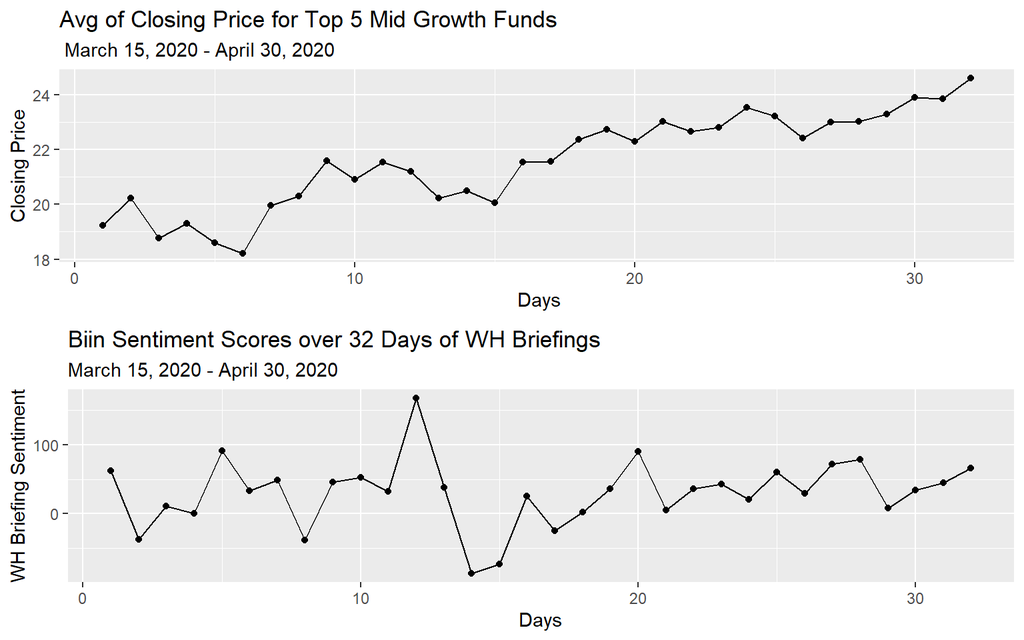

```r
plot1 <- tst2Frame %>%
ggplot(aes(x=Day, y=AvgClose, group=1)) +
    geom_line() +
    geom_point() + labs(x=" Days", y="Closing Price", title = "Avg of Closing Price for Top 5 Mid Growth Funds", subtitle = " March 15, 2020 - April 30, 2020")

plot2 <- tst2Frame %>%
ggplot(aes(x=Day, y=Sentiment, group=1)) +
    geom_line() +
    geom_point() + labs(x="Days", y="WH Briefing Sentiment", title = "Biin Sentiment Scores over 32 Days of WH Briefings", subtitle = "March 15, 2020 - April 30, 2020")

grid.arrange(plot1, plot2, nrow = 2)
```

```r
lgFrame <- dateFrame
colnames(lgFrame) <- c("Date","Day")

lgFrame$TRLGX_Close <- TRLGX$TRLGX.Close
lgFrame$PREFX_Close <- PREFX$PREFX.Close
lgFrame$TPLGX_Close <- TPLGX$TPLGX.Close
lgFrame$FDSVX_Close <- FDSVX$FDSVX.Close
lgFrame$PBLAX_Close <- PBLAX$PBLAX.Close


lgFrame$Sentiment <- wh.bing$sentiment
```

```r
tst3Frame <- lgFrame

tst3Frame$AvgClose <- (TRLGX$TRLGX.Close + PREFX$PREFX.Close + TPLGX$TPLGX.Close + FDSVX$FDSVX.Close + PBLAX$PBLAX.Close)/5

SmLm4 <- lm(AvgClose ~ Sentiment, data= tst3Frame)

summary(SmLm4)
```

```
##
## Call:
## lm(formula = AvgClose ~ Sentiment, data = tst3Frame)
##
## Residuals:
##     Min      1Q  Median      3Q     Max
## -5.2845 -1.9643  0.3148  2.2355  3.9929
##
## Coefficients:
##              Estimate Std. Error t value Pr(>|t|)
## (Intercept) 34.300249   0.570832  60.088   <2e-16 ***
## Sentiment    0.011255   0.009996   1.126    0.269
## ---
## Signif. codes:  0 '***' 0.001 '**' 0.01 '*' 0.05 '.' 0.1 ' ' 1
##
## Residual standard error: 2.734 on 30 degrees of freedom
## Multiple R-squared:  0.04055,    Adjusted R-squared:  0.008564
## F-statistic: 1.268 on 1 and 30 DF,  p-value: 0.2691
```

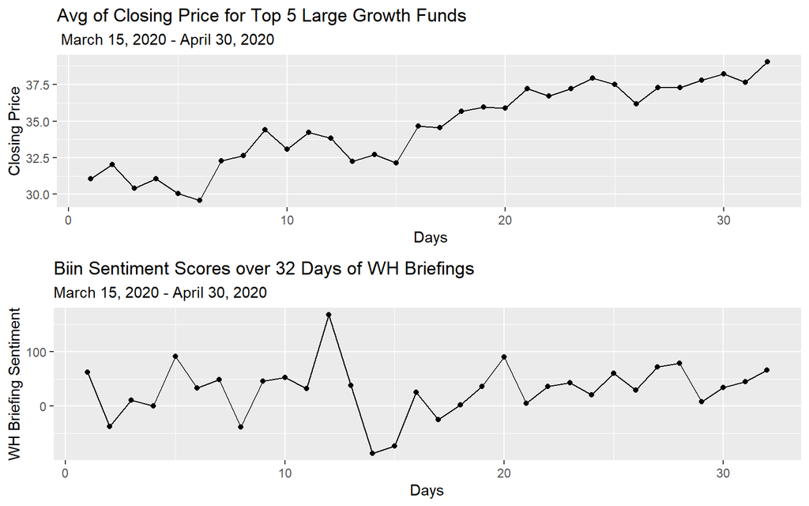

```r
plot1 <- tst3Frame %>%
ggplot(aes(x=Day, y=AvgClose, group=1)) +
    geom_line() +
    geom_point() + labs(x=" Days", y="Closing Price", title = "Avg of Closing Price for Top 5 Large Growth Funds", subtitle = " March 15, 2020 - April 30, 2020")

plot2 <- tst3Frame %>%
ggplot(aes(x=Day, y=Sentiment, group=1)) +
    geom_line() +
    geom_point() + labs(x="Days", y="WH Briefing Sentiment", title = "Biin Sentiment Scores over 32 Days of WH Briefings", subtitle = "March 15, 2020 - April 30, 2020")

grid.arrange(plot1, plot2, nrow = 2)
```

# Challenges * Incorpating such different data into one graph for comparison * Twitter data was only available for the past 8 days, so we were unable to chart this data over time

# Resources

- https://bradleyboehmke.github.io/2015/12/scraping-html-text.html
- Automated Data Collection PDF Book
- https://projects.fivethirtyeight.com/trump-approval-ratings/